← Back to Project Report

# Unsupervised Learning Analysis for E-Commerce Orders Segmentation

Building on the cleaned e-commerce dataset established in our data preprocessing phase, this report applies unsupervised learning techniques to uncover latent structure within order behavior. Specifically, we pursue two complementary objectives:

1. **Customer Order Segmentation via K-Means Clustering** — grouping orders by their numerical characteristics (basket value, quantity, freight proportion, and product diversity) to identify distinct purchasing profiles that can inform targeted marketing and logistics strategies.
2. **Market Basket Analysis via Association Rule Mining** — discovering statistically significant co-occurrence patterns between product categories, payment methods, and order sizes to surface actionable cross-sell and promotional opportunities.

Together, these analyses translate raw transactional data into strategic business intelligence.

### Setup

The following libraries underpin the full analytical pipeline. `pandas` and `numpy` handle data manipulation; `matplotlib` and `seaborn` drive visualization; `sklearn` provides preprocessing and clustering utilities; and `mlxtend` supports the Apriori-based association rule mining workflow.

```python
import pandas as pd
import numpy as np
import matplotlib.pyplot as plt
import seaborn as sns

from sklearn.model_selection import train_test_split
from sklearn.preprocessing import StandardScaler
from sklearn.cluster import KMeans

from mlxtend.preprocessing import TransactionEncoder
from mlxtend.frequent_patterns import apriori, association_rules

plt.style.use('seaborn-v0_8')
```

## Part 1: Data Ingestion

We load the consolidated, cleaned dataset produced during the data preprocessing phase — a single order-level file (`ecommerce_orders_cleaned.csv`) representing the merged and validated output of the original `orders`, `order_items`, `order_shipping`, and `payments` tables. This serves as the authoritative source of truth for all downstream analysis.

```python
# Load the cleaned dataset
from pathlib import Path

csv_path = Path(__file__).parent / "ecommerce_orders_cleaned.csv" if "__file__" in dir() else Path("../AS3/ecommerce_orders_cleaned.csv")
df = pd.read_csv(csv_path)

print(df.shape)
df.head()
```

```
(46287, 17)
```

|  | order_id | order_status | order_purchase_hour | order_purchase_dayofweek | order_purchase_month | order_total_value | num_items | num_unique_products | num_unique_sellers | total_item_price | avg_item_price | total_freight_value | top_product_category | customer_state | payment_type | order_value_per_item | order_size_category |
| --- | --- | --- | --- | --- | --- | --- | --- | --- | --- | --- | --- | --- | --- | --- | --- | --- | --- |
| 0 | sdv-id-whzjUX | shipped | 10 | 4 | 4 | 744.312535 | 1 | 1 | 1 | 352.420029 | 369.966521 | 68.790159 | construction_tools_construction | Massachusetts | voucher | 352.420029 | Small |
| 1 | sdv-id-dbopoJ | delivered | 19 | 2 | 3 | 1556.667902 | 1 | 1 | 1 | 289.242639 | 1354.621410 | 15.394619 | health_beauty | Vermont | credit_card | 289.242639 | Small |
| 2 | sdv-id-FSEOvM | delivered | 15 | 4 | 8 | 62.060506 | 1 | 1 | 1 | 26.893468 | 48.485654 | 18.751282 | luggage_accessories | South Carolina | debit_card | 26.893468 | Small |
| 3 | sdv-id-bQcBUR | delivered | 21 | 0 | 8 | 73.873470 | 1 | 1 | 1 | 37.790896 | 75.704909 | 8.670875 | computers_accessories | Kentucky | credit_card | 37.790896 | Small |
| 4 | sdv-id-MPxIXB | delivered | 13 | 5 | 5 | 361.961537 | 3 | 3 | 3 | 169.528323 | 50.132979 | 34.731146 | pet_shop | Missouri | voucher | 56.509441 | Medium |

## Part 2: Unsupervised Learning

### Objective

With a clean order-level dataset in hand, we apply unsupervised learning to surface hidden structure in purchasing behavior. The goal is to group orders by shared numerical characteristics — order value, item quantity, freight proportion, and product variety — into distinct customer segments. These segments form the basis for targeted promotions, differentiated logistics planning, and personalized recommendation strategies.

### Data Preprocessing for Unsupervised Learning

#### Constructing the Order-Level Feature Matrix (`all_orders_df`)

Before clustering can be applied, the dataset must be structured so that each row represents exactly one order. From the cleaned dataset, we extract and derive the following features:

- **`basket_size`** — total monetary value of the order
- **`basket_qty`** — total number of items
- **`freight_ratio`** — the share of the order value attributable to shipping (`total_freight_value / order_total_value`), a proxy for logistics intensity
- **`product_diversity`** — the breadth of distinct product types relative to basket size (`num_unique_products / num_items`), capturing whether customers shop narrowly or broadly
- **`top_product_category`**, **`payment_type`**, **`order_size_category`** — categorical dimensions used later in association mining

Division-by-zero cases (zero-value or empty orders) are handled explicitly. Remaining missing values in categorical columns are replaced with `"Unknown"`, and numerical columns are zero-filled.

```python
# Construct all_orders_df — one row per order with derived clustering features

# one row per order
base = df.drop_duplicates(subset=["order_id"]).copy()

# required columns + renamed fields
all_orders_df = pd.DataFrame({
    "order_id": base["order_id"],
    "basket_size": base["order_total_value"],
    "basket_qty": base["num_items"],
    "top_product_category": base["top_product_category"],
    "payment_type": base["payment_type"],
    "order_size_category": base["order_size_category"],
})

# derived features (safe division)
all_orders_df["freight_ratio"] = np.where(
    base["order_total_value"] > 0,
    base["total_freight_value"] / base["order_total_value"],
    0.0
)

all_orders_df["product_diversity"] = np.where(
    base["num_items"] > 0,
    base["num_unique_products"] / base["num_items"],
    0.0
)

# handle missing values
cat_cols = ["top_product_category", "payment_type", "order_size_category"]
num_cols = ["basket_size", "basket_qty", "freight_ratio", "product_diversity"]

all_orders_df[cat_cols] = all_orders_df[cat_cols].fillna("Unknown")
all_orders_df[num_cols] = all_orders_df[num_cols].fillna(0)

# optional checks
print("Unique order_id:", all_orders_df["order_id"].nunique())
print("Rows:", len(all_orders_df))
print("Missing values:\n", all_orders_df.isna().sum())

print(all_orders_df.head(10))
print("Shape:", all_orders_df.shape)
print(all_orders_df.dtypes)
```

```
Unique order_id: 46287
Rows: 46287
Missing values:
 order_id                0
basket_size             0
basket_qty              0
top_product_category    0
payment_type            0
order_size_category     0
freight_ratio           0
product_diversity       0
dtype: int64
        order_id  basket_size  basket_qty             top_product_category  \
0  sdv-id-whzjUX   744.312535           1  construction_tools_construction
1  sdv-id-dbopoJ  1556.667902           1                    health_beauty
2  sdv-id-FSEOvM    62.060506           1              luggage_accessories
3  sdv-id-bQcBUR    73.873470           1            computers_accessories
4  sdv-id-MPxIXB   361.961537           3                         pet_shop
5  sdv-id-ySodbB   867.750230           7                   sports_leisure
6  sdv-id-wdwBrk    55.965822           2                             toys
7  sdv-id-maBYtk   170.295452           3            computers_accessories
8  sdv-id-oodUXj    83.065603           1                  furniture_decor
9  sdv-id-zroJIL    98.250248           1         fashion_bags_accessories

  payment_type order_size_category  freight_ratio  product_diversity
0      voucher               Small       0.092421           1.000000
1  credit_card               Small       0.009889           1.000000
2   debit_card               Small       0.302145           1.000000
3  credit_card               Small       0.117375           1.000000
4      voucher              Medium       0.095953           1.000000
5      voucher               Large       0.204442           0.857143
6       points               Small       0.285101           0.500000
7      voucher              Medium       0.089290           1.000000
8      voucher               Small       0.236471           1.000000
9       points               Small       0.369709           1.000000
Shape: (46287, 8)
order_id                    str
basket_size             float64
basket_qty                int64
top_product_category        str
payment_type                str
order_size_category         str
freight_ratio           float64
product_diversity       float64
dtype: object
```

### Sampling for Cluster Exploration (`orders_analysis_df`)

```python
# Sample 30% of all_orders_df for cluster-count selection (analysis subset)

_, orders_analysis_df = train_test_split(
    all_orders_df, test_size=0.3, random_state=37
)

print("Shape of orders_analysis_df:", orders_analysis_df.shape)
print("\nFirst 10 rows of orders_analysis_df:")
print(orders_analysis_df.head(10))
```

```
Shape of orders_analysis_df: (13887, 8)

First 10 rows of orders_analysis_df:
            order_id  basket_size  basket_qty      top_product_category  \
1882   sdv-id-ISddRn   132.611695           1        christmas_supplies
40995  sdv-id-GmlErp   730.510053           6           furniture_decor
40104  sdv-id-BWpket   632.486142           1            bed_bath_table
25808  sdv-id-krmbPT    47.102393           1                 telephony
23294  sdv-id-vhfMmG   133.285008           1             health_beauty
7160   sdv-id-kcTYfM   403.696187           2                      auto
7180   sdv-id-tFFFCg   211.465148           2           furniture_decor
20801  sdv-id-KgDKAA    57.520738           1            bed_bath_table
19879  sdv-id-cfCjEB   576.212699           3            bed_bath_table
39874  sdv-id-uxRZME   141.772602           2  fashion_bags_accessories

      payment_type order_size_category  freight_ratio  product_diversity
1882       voucher               Small       0.126285           1.000000
40995  credit_card               Large       0.075288           0.666667
40104  credit_card               Small       0.051262           1.000000
25808  credit_card               Small       0.248932           1.000000
23294   debit_card               Small       0.135860           1.000000
7160   credit_card               Small       0.079065           0.500000
7180       voucher               Small       0.162263           1.000000
20801  credit_card               Small       0.228879           1.000000
19879  credit_card              Medium       0.056350           0.666667
39874  credit_card               Small       0.200719           1.000000
```

### Determining the Optimal Number of Clusters

#### K-Means Inertia Sweep (k = 3 to 9)

Before committing to a cluster count, we systematically evaluate K-Means across a range of values (k = 3 to 9) on the analysis sample. Only the four numerical features — `basket_size`, `basket_qty`, `freight_ratio`, and `product_diversity` — are used, as clustering on raw numerical scales would bias results toward high-magnitude features. All features are therefore standardized using `StandardScaler` prior to fitting.

For each k, we record the **inertia** — the sum of squared distances between each order and its assigned cluster centroid. Inertia decreases monotonically as k increases; the objective is to identify the point at which additional clusters yield diminishing returns in compactness.

```python
# K-Means inertia sweep across k = 3 to 9 on standardized numerical features

num_cols = ["basket_size", "basket_qty", "freight_ratio", "product_diversity"]
X = orders_analysis_df[num_cols].copy()

scaler = StandardScaler()
X_scaled = scaler.fit_transform(X)

k_values = list(range(3, 10))
inertia_values = []

for k in k_values:
    km = KMeans(n_clusters=k, random_state=37, n_init=10)
    km.fit(X_scaled)
    inertia_values.append(km.inertia_)

inertia_table = pd.DataFrame({"k": k_values, "inertia": inertia_values})
inertia_table
```

|  | k | inertia |
| --- | --- | --- |
| 0 | 3 | 28884.287460 |
| 1 | 4 | 21464.393895 |
| 2 | 5 | 17303.035640 |
| 3 | 6 | 15013.968444 |
| 4 | 7 | 13219.438102 |
| 5 | 8 | 11762.794068 |
| 6 | 9 | 10516.159393 |

### Elbow Method — Selecting the Optimal k

The Elbow Method plots inertia against k to visually identify the inflection point at which the marginal gain in cluster compactness begins to plateau. This inflection — the "elbow" — represents the most parsimonious cluster count: enough structure to be meaningful, without overfitting spurious micro-segments.

Based on the plot below, we select **k = 4** as the optimal configuration, as this marks a clear change in the rate of inertia reduction before the curve smooths out further.

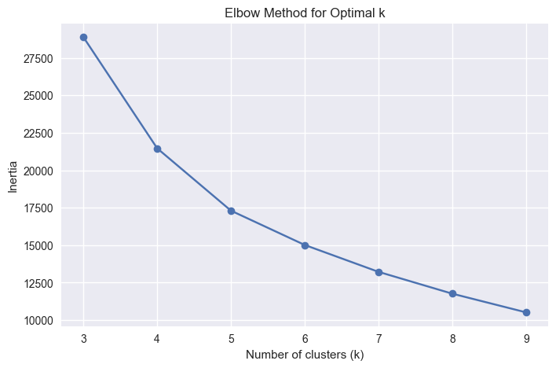

```python
# Elbow Method — plot inertia vs k to identify the optimal cluster count

plt.figure(figsize=(8, 5))
plt.plot(k_values, inertia_values, marker='o', linestyle='-')
plt.title('Elbow Method for Optimal k')
plt.xlabel('Number of clusters (k)')
plt.ylabel('Inertia')
plt.xticks(k_values)
plt.grid(True)
plt.show()
optimal_k = 4
```

### Cluster Analysis and Visualization

#### Assigning Clusters to the Full Dataset

With the optimal cluster count established at k = 4, we re-fit K-Means on the **full** `all_orders_df` using the same four standardized numerical features. Each order is assigned a cluster label, appended as a `cluster` column. Fitting on the complete dataset ensures that all orders — not just the analysis sample — carry a meaningful segment assignment for downstream profiling and recommendation logic.

```python
# Fit K-Means with optimal k on the full dataset and assign cluster labels

X_all = all_orders_df[num_cols].copy()

scaler_all = StandardScaler()
X_all_scaled = scaler_all.fit_transform(X_all)

kmeans_final = KMeans(n_clusters=optimal_k, random_state=37, n_init=10)
all_orders_df["cluster"] = kmeans_final.fit_predict(X_all_scaled)

all_orders_df.head(10)
```

|  | order_id | basket_size | basket_qty | top_product_category | payment_type | order_size_category | freight_ratio | product_diversity | cluster |
| --- | --- | --- | --- | --- | --- | --- | --- | --- | --- |
| 0 | sdv-id-whzjUX | 744.312535 | 1 | construction_tools_construction | voucher | Small | 0.092421 | 1.000000 | 2 |
| 1 | sdv-id-dbopoJ | 1556.667902 | 1 | health_beauty | credit_card | Small | 0.009889 | 1.000000 | 3 |
| 2 | sdv-id-FSEOvM | 62.060506 | 1 | luggage_accessories | debit_card | Small | 0.302145 | 1.000000 | 0 |
| 3 | sdv-id-bQcBUR | 73.873470 | 1 | computers_accessories | credit_card | Small | 0.117375 | 1.000000 | 2 |
| 4 | sdv-id-MPxIXB | 361.961537 | 3 | pet_shop | voucher | Medium | 0.095953 | 1.000000 | 2 |
| 5 | sdv-id-ySodbB | 867.750230 | 7 | sports_leisure | voucher | Large | 0.204442 | 0.857143 | 3 |
| 6 | sdv-id-wdwBrk | 55.965822 | 2 | toys | points | Small | 0.285101 | 0.500000 | 1 |
| 7 | sdv-id-maBYtk | 170.295452 | 3 | computers_accessories | voucher | Medium | 0.089290 | 1.000000 | 2 |
| 8 | sdv-id-oodUXj | 83.065603 | 1 | furniture_decor | voucher | Small | 0.236471 | 1.000000 | 0 |
| 9 | sdv-id-zroJIL | 98.250248 | 1 | fashion_bags_accessories | points | Small | 0.369709 | 1.000000 | 0 |

### Cluster Profiling and Visualization

Two complementary visualizations are produced to characterize and communicate the resulting segments:

**Cluster Profile Heatmap** — Computes the mean of each numerical feature per cluster, then re-standardizes these means as Z-scores so that features measured in different units (currency vs. counts vs. ratios) can be directly compared. A diverging colormap distinguishes clusters that score above average (positive Z-score, red) from those below average (negative Z-score, blue) on each dimension, providing an at-a-glance segment fingerprint.

**Cluster Size Distribution** — A bar chart showing order volume per cluster. This reveals whether the segmentation produces balanced groups or whether certain segments dominate, which has direct implications for how broadly any cluster-specific strategy can be deployed.

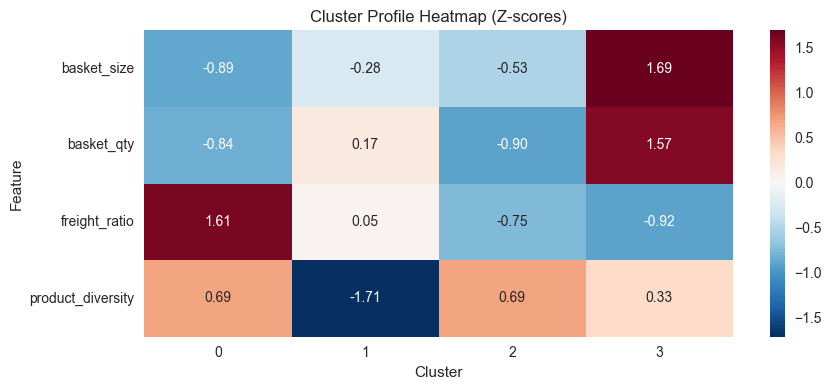

```python
# Cluster Profile Heatmap — Z-scored mean features per cluster

cluster_means = all_orders_df.groupby("cluster")[num_cols].mean()

z_scaler = StandardScaler()
cluster_means_z = pd.DataFrame(
    z_scaler.fit_transform(cluster_means),
    index=cluster_means.index,
    columns=cluster_means.columns
)

plt.figure(figsize=(9, 4))
sns.heatmap(
    cluster_means_z.T,
    cmap="RdBu_r",
    annot=True,
    fmt=".2f",
    center=0
)
plt.title("Cluster Profile Heatmap (Z-scores)")
plt.xlabel("Cluster")
plt.ylabel("Feature")
plt.tight_layout()
plt.show()
```

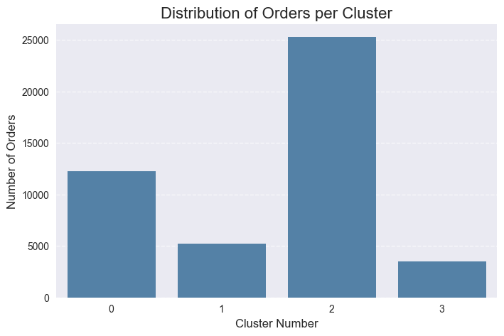

```python
# Cluster Size Distribution — order volume per segment
cluster_counts = all_orders_df["cluster"].value_counts().sort_index()

plt.figure(figsize=(8, 5))
sns.barplot(x=cluster_counts.index, y=cluster_counts.values, color="steelblue")
plt.title("Distribution of Orders per Cluster", fontsize=16)
plt.xlabel("Cluster Number", fontsize=12)
plt.ylabel("Number of Orders", fontsize=12)
plt.xticks(rotation=0)
plt.grid(axis="y", linestyle="--", alpha=0.7)
plt.show()
```

### Cluster Interpretation

1. The heatmap shows moderate-to-strong separation: Cluster 3 is clearly high in `basket_size` and `basket_qty` with low `freight_ratio`, while Cluster 0 shows the opposite pattern (low value/quantity but high freight burden). As for Cluster 2, its samples are less differentiated based on the moderate Z-scores compared to other clusters.
2. `basket_size` and `freight_ratio` are the strongest defining features because they have the largest absolute Z-score contrasts compared to other clusters, with `basket_qty` as a secondary differentiator and `product_diversity` mainly distinguishing Cluster 1. This is because monetary value and shipping costs represent the primary economic trade-offs in e-commerce; for example, high-value items often require specialized logistics, naturally separating "Premium/Bulky" orders from "Standard" ones.
3. The clusters represent distinct purchasing behaviors, including high-value buyers, low-diversity shoppers, bulk purchasers, and customers paying higher freight costs. These behavioral differences allow the e-commerce business to design targeted promotions and operational strategies tailored to each customer segment.

### Market Basket Analysis (Association Rule Mining)

#### Methodology Overview

Market Basket Analysis is an unsupervised technique that quantifies co-occurrence patterns across discrete transaction attributes. Rather than predicting an outcome, it surfaces rules of the form *"when X is present, Y is also present with high probability"* — invaluable for understanding multi-dimensional customer behavior.

In the e-commerce context, this helps answer questions such as:

- Which payment methods are preferred for which product categories?
- Do certain order sizes correlate with specific product types?
- What multi-attribute patterns exist across category, payment channel, and basket size?

Association rules are evaluated along three key metrics:

| Metric | Definition |
| --- | --- |
| **Support** | How frequently a pattern appears across all transactions (0–1) |
| **Confidence** | Probability of the consequent given the antecedent (0–1) |
| **Lift** | How much more likely the rule is versus random chance (> 1 = positive association) |

We apply the **Apriori algorithm** to the categorical features of `all_orders_df` to discover frequent itemsets and generate high-lift rules.

### Transaction Encoding

To apply the Apriori algorithm, each order must be represented as a "basket" of discrete items. We construct a transaction list where each order contributes exactly three tagged items—one per categorical dimension:

- `cat_{top_product_category}` — the dominant product category
- `pay_{payment_type}` — the payment method used
- `size_{order_size_category}` — the order size class (Small / Medium / Large)

The prefixes ensure items from different dimensions remain distinguishable after encoding.

```python
# Build the transaction list — each order as a basket of 3 tagged categorical items

# Create the transactions list using a list comprehension for efficiency
transactions = [
    [
        f"cat_{row['top_product_category']}",
        f"pay_{row['payment_type']}",
        f"size_{row['order_size_category']}"
    ]
    for _, row in all_orders_df.iterrows()
]

# Display the first 5 transactions to verify the format
print(f"Total transactions: {len(transactions)}")
print("\nFirst 5 transactions (Baskets):")
for i in range(5):
    print(f"Order {i+1}: {transactions[i]}")
```

```
Total transactions: 46287

First 5 transactions (Baskets):
Order 1: ['cat_construction_tools_construction', 'pay_voucher', 'size_Small']
Order 2: ['cat_health_beauty', 'pay_credit_card', 'size_Small']
Order 3: ['cat_luggage_accessories', 'pay_debit_card', 'size_Small']
Order 4: ['cat_computers_accessories', 'pay_credit_card', 'size_Small']
Order 5: ['cat_pet_shop', 'pay_voucher', 'size_Medium']
```

### Apriori Algorithm — Frequent Itemsets and Rule Generation

Using the `mlxtend` library, the workflow proceeds in three steps:

1. **One-hot encoding** via `TransactionEncoder` — converts the transaction list into a Boolean DataFrame where each column represents a unique item.
2. **Frequent itemset mining** via `apriori()` with `min_support = 0.01` — retains only item combinations appearing in at least 1% of all orders, balancing pattern coverage against noise.
3. **Rule generation** via `association_rules()` with `metric = 'lift'` and `min_threshold = 1.0` — produces all rules where co-occurrence is at least as likely as independent random chance.

```python
# Step 1: One-hot encode the transaction list using TransactionEncoder

te = TransactionEncoder()
te_array = te.fit(transactions).transform(transactions)
trans_df = pd.DataFrame(te_array, columns=te.columns_)
print(f"Shape of encoded DataFrame: {trans_df.shape}")
print("Encoded shape:", trans_df.shape)
trans_df.head()
```

```
Shape of encoded DataFrame: (46287, 79)
Encoded shape: (46287, 79)
```

|  | cat_agro_industry_and_commerce | cat_air_conditioning | cat_art | cat_arts_and_craftmanship | cat_audio | cat_auto | cat_baby | cat_bed_bath_table | cat_books_general_interest | cat_books_imported | ... | cat_toys | cat_watches_gifts | pay_credit_card | pay_debit_card | pay_not_defined | pay_points | pay_voucher | size_Large | size_Medium | size_Small |
| --- | --- | --- | --- | --- | --- | --- | --- | --- | --- | --- | --- | --- | --- | --- | --- | --- | --- | --- | --- | --- | --- |
| 0 | False | False | False | False | False | False | False | False | False | False | ... | False | False | False | False | False | False | True | False | False | True |
| 1 | False | False | False | False | False | False | False | False | False | False | ... | False | False | True | False | False | False | False | False | False | True |
| 2 | False | False | False | False | False | False | False | False | False | False | ... | False | False | False | True | False | False | False | False | False | True |
| 3 | False | False | False | False | False | False | False | False | False | False | ... | False | False | True | False | False | False | False | False | False | True |
| 4 | False | False | False | False | False | False | False | False | False | False | ... | False | False | False | False | False | False | True | False | True | False |

5 rows × 79 columns

```python
# Step 2: Apply Apriori to mine frequent itemsets (min_support = 0.01)

frequent_itemsets = apriori(trans_df, min_support=0.01, use_colnames=True)
print("Frequent itemsets:", len(frequent_itemsets))
frequent_itemsets.head()
```

```
Frequent itemsets: 102
```

|  | support | itemsets |
| --- | --- | --- |
| 0 | 0.030592 | frozenset({cat_auto}) |
| 1 | 0.023592 | frozenset({cat_baby}) |
| 2 | 0.138678 | frozenset({cat_bed_bath_table}) |
| 3 | 0.073152 | frozenset({cat_computers_accessories}) |
| 4 | 0.016311 | frozenset({cat_consoles_games}) |

```python
# Step 3: Generate association rules filtered by lift >= 1.0

rules = association_rules(frequent_itemsets, metric="lift", min_threshold=1.0)
print("Rules generated:", len(rules))
rules.head()
```

```
Rules generated: 138
```

|  | antecedents | consequents | antecedent support | consequent support | support | confidence | lift | representativity | leverage | conviction | zhangs_metric | jaccard | certainty | kulczynski |
| --- | --- | --- | --- | --- | --- | --- | --- | --- | --- | --- | --- | --- | --- | --- |
| 0 | frozenset({pay_credit_card}) | frozenset({cat_auto}) | 0.604641 | 0.030592 | 0.020503 | 0.033909 | 1.108423 | 1.0 | 0.002006 | 1.003433 | 0.247414 | 0.033352 | 0.003422 | 0.352053 |
| 1 | frozenset({cat_auto}) | frozenset({pay_credit_card}) | 0.030592 | 0.604641 | 0.020503 | 0.670198 | 1.108423 | 1.0 | 0.002006 | 1.198777 | 0.100904 | 0.033352 | 0.165817 | 0.352053 |
| 2 | frozenset({pay_credit_card}) | frozenset({cat_baby}) | 0.604641 | 0.023592 | 0.015015 | 0.024833 | 1.052604 | 1.0 | 0.000750 | 1.001273 | 0.126403 | 0.024486 | 0.001271 | 0.330640 |
| 3 | frozenset({cat_baby}) | frozenset({pay_credit_card}) | 0.023592 | 0.604641 | 0.015015 | 0.636447 | 1.052604 | 1.0 | 0.000750 | 1.087487 | 0.051182 | 0.024486 | 0.080449 | 0.330640 |
| 4 | frozenset({size_Small}) | frozenset({cat_baby}) | 0.864735 | 0.023592 | 0.020913 | 0.024184 | 1.025108 | 1.0 | 0.000512 | 1.000607 | 0.181074 | 0.024110 | 0.000607 | 0.455316 |

### Top 10 Rules by Lift

Rules are ranked by **lift** in descending order to surface the most statistically surprising — and therefore most actionable — associations. For reference, rules with lift > 1.5 are considered strong associations; lift > 2.0 indicates a very strong co-occurrence.

```python
# Rank rules by lift (descending) and display the top 10 most surprising associations

# Step 1. Sort rules by Lift in descending order
top_rules = rules.sort_values(by='lift', ascending=False).head(10)

# Step 2. Select only the required columns for clarity
# We convert frozensets to strings/lists for better readability in the table
top_rules_display = top_rules[['antecedents', 'consequents', 'support', 'confidence', 'lift']].copy()
top_rules_display['antecedents'] = top_rules_display['antecedents'].apply(lambda x: list(x))
top_rules_display['consequents'] = top_rules_display['consequents'].apply(lambda x: list(x))

# Step 3. Display the table
print("Top 10 Association Rules (Sorted by Lift):")
display(top_rules_display)
```

```
Top 10 Association Rules (Sorted by Lift):
```

|  | antecedents | consequents | support | confidence | lift |
| --- | --- | --- | --- | --- | --- |
| 24 | [size_Large] | [cat_furniture_decor] | 0.014583 | 0.392899 | 5.328480 |
| 25 | [cat_furniture_decor] | [size_Large] | 0.014583 | 0.197773 | 5.328480 |
| 73 | [size_Medium, pay_credit_card] | [cat_bed_bath_table] | 0.016851 | 0.280576 | 2.023212 |
| 76 | [cat_bed_bath_table] | [size_Medium, pay_credit_card] | 0.016851 | 0.121514 | 2.023212 |
| 75 | [size_Medium] | [pay_credit_card, cat_bed_bath_table] | 0.016851 | 0.171693 | 1.757439 |
| 74 | [pay_credit_card, cat_bed_bath_table] | [size_Medium] | 0.016851 | 0.172490 | 1.757439 |
| 27 | [cat_furniture_decor] | [size_Medium] | 0.012660 | 0.171696 | 1.749354 |
| 26 | [size_Medium] | [cat_furniture_decor] | 0.012660 | 0.128990 | 1.749354 |
| 8 | [size_Medium] | [cat_bed_bath_table] | 0.022749 | 0.231785 | 1.671388 |
| 9 | [cat_bed_bath_table] | [size_Medium] | 0.022749 | 0.164044 | 1.671388 |

### Business Recommendations

- **Prioritize large furniture baskets with payment support:** For customers in `cat_furniture_decor` with `size_Large`, offer installment/BNPL and targeted checkout promotions to reduce abandonment on high-ticket (expensive) orders to hit credit card rebates.
- **Run medium-basket card promotions:** Since medium baskets are strongly linked with card payment patterns, launch category-specific credit-card cashback bundles (especially home/bed-bath-related items).
- **Deploy rule-based cross-sell recommendations:** Use high-lift pairs in cart and checkout ("frequently bought together" by category + size) to increase average order value and conversion.

← Back to Project Report